# Linear Regression

Lecture 1

Dr. Emre Yucel

2026-08-26

# Simple Regression

## Data description:

- Subset of single family home sales in 3 Austin zipcodes
- Variables include location, size, number of bedrooms, number of bathrooms, and many more
- Focus on relationship between price, number of bedrooms, and living area (square feet) as a first example

## Price vs bedrooms

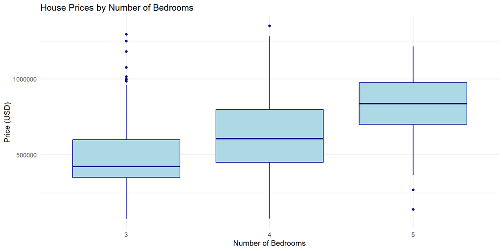

Figure 1: House Prices by Number of Bedrooms

## Price vs bedrooms

- On average, more bedrooms = higher price
- Variability among houses with any given number of bedrooms – why?
  - Other factors not in the model
  - “Random” variation (who is in and out of the market, buyer/seller motivation, etc)

## Price vs bedrooms

```r
# Linear regression of price on beds
model_bed <- lm(price ~ beds, data = houses)
summary(model_bed)
```

```
Call:
lm(formula = price ~ beds, data = houses)

Residuals:
    Min      1Q  Median      3Q     Max
-657616 -151806  -46830  138220  808220

Coefficients:
            Estimate Std. Error t value Pr(>|t|)
(Intercept)    20527      60308  0.3404   0.7337
beds          155418      17355  8.9551   <2e-16 ***
---
Signif. codes:  0 '***' 0.001 '**' 0.01 '*' 0.05 '.' 0.1 ' ' 1

Residual standard error: 229040 on 506 degrees of freedom
Multiple R-squared:  0.1368,    Adjusted R-squared:  0.1351
F-statistic: 80.193 on 1 and 506 DF,  p-value: < 2.22e-16
```

## Reading the regression table

- For now, focus on the coefficients:
  - Intercept $\hat\beta_0$: $20,527
  - Slope $\hat\beta_1$: $155,418
  - Fitted line:
    $$\widehat{price} = 20,527 + 155,418 \times beds$$

## Visualizing the fit

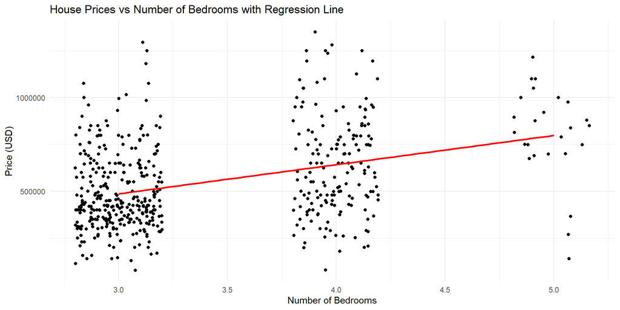

Figure 2: House Prices vs Number of Bedrooms with Regression Line

## Price vs living area

- Only three distinct values for `bedrooms`
- Let’s look at a continuous predictor: living area (square feet)

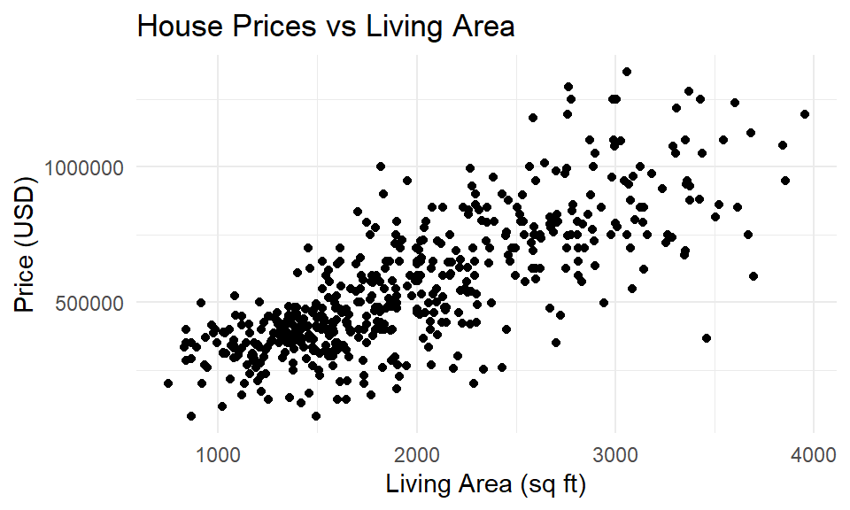

## Practice

Find the intercept and slope in the regression output below, and write the equation predicting price from living area

```r
# Linear regression of price on area
model_area <- lm(price ~ area, data = houses)
summary(model_area)
```

```
Call:
lm(formula = price ~ area, data = houses)

Residuals:
    Min      1Q  Median      3Q     Max
-604840  -90641    2955   83298  519720

Coefficients:
             Estimate Std. Error t value Pr(>|t|)
(Intercept)  4296.668  21017.955  0.2044   0.8381
area          279.139     10.101 27.6337   <2e-16 ***
---
Signif. codes:  0 '***' 0.001 '**' 0.01 '*' 0.05 '.' 0.1 ' ' 1

Residual standard error: 155630 on 506 degrees of freedom
Multiple R-squared:  0.60146,   Adjusted R-squared:  0.60067
F-statistic: 763.62 on 1 and 506 DF,  p-value: < 2.22e-16
```

## Practice

- Intercept: $\hat\beta_0$: 4297
- Slope: $\hat\beta_1$: 279.14
- Fitted line:
  $$\widehat{\text{price}} = 4297 + 279.14 \times \text{area}$$

## Visualizing the fit

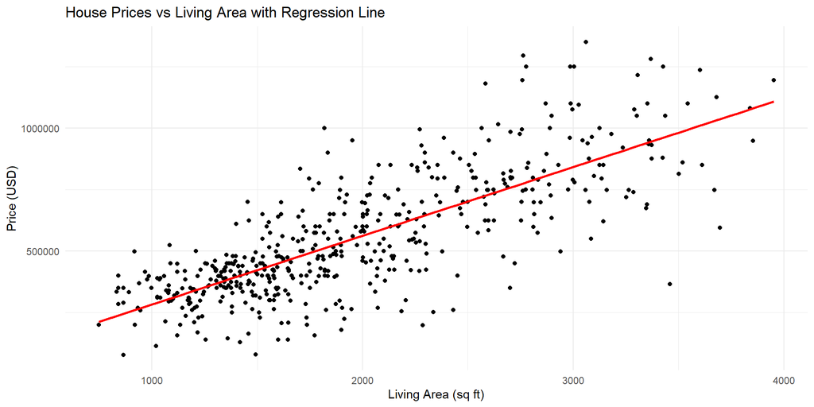

## OK who cares?

Linear regression has two basic use cases:

1. To generate predictions
2. To understand how changes in the predictors X relate to changes in the actual or predicted outcome Y

## Making predictions

- Say I want to predict the sale price of a newly listed house with 2,000 sq ft of living area
- Using our model, my guess is

$$\widehat{\text{price}} \approx 4297 + 279.14 \times 2000 = 562577$$
(Without rounding the intercept/slope we get $562,576)

## Making predictions (graphically)

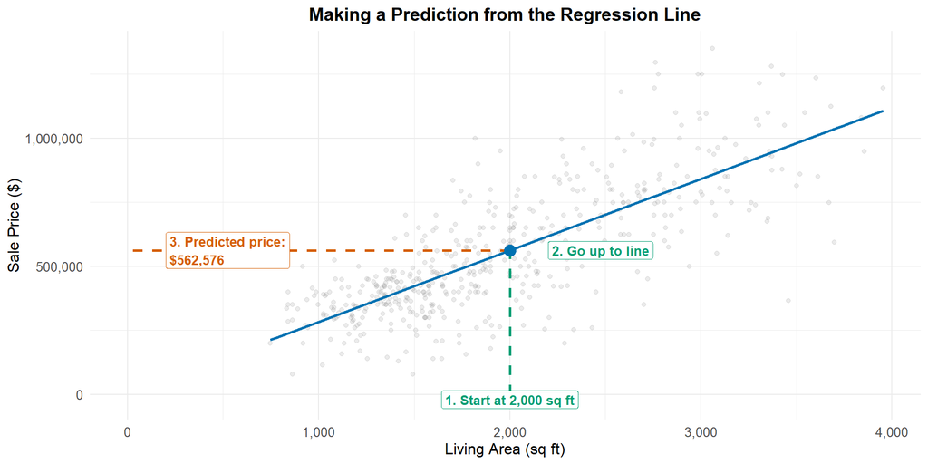

## Making predictions

- You should know how to do this by hand (read off the linear equation, plug in the x value, calculate the prediction)
- That’s how you check your understanding
- But in practice, you’ll usually use R to do this for you

```r
# Predict price for new data point
new_data <- data.frame(area = 2000)
predicted_price <- predict(model_area, newdata = new_data)
predicted_price
```

```
        1
562575.52
```

## Interpreting the predicted value

- The predicted price for a house with 2,000 sq ft of living area is $562,576
  - For a newly listed 2,000 sqft house, this is our best guess at the sale price
  - It is also the *estimated **average** sale price* for *all* houses with 2,000 sq ft of living area in these three Austin zips
- Think about the regression prediction as the model’s estimated average outcome for all similar units (2000 sqft houses)

## Summarizing relationships

- We can use the fitted model to summarize the relationship between X’s (predictors) and Y (outcome)
- The **slope** tells us how much the predicted outcome (price) changes for a one unit increase in the predictor (area)
  - For each additional square foot of living area, the predicted price increases by $279.14
  - Comparing two houses that differ in size by one sqft, the larger house has predicted price that is $279.14 higher

## Interpreting the slope

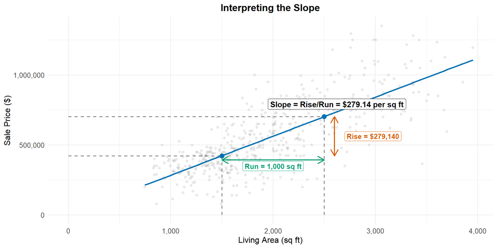

## Interpreting the slope

- Remember, we can think about the prediction as the (estimated) average outcome for all units with that X value
- So the slope also tells us:
  - If we compare two houses that differ in size by 1 sqft, the larger house has a predicted value that is $279.14 higher
  - On average, houses that are 1 sqft larger sell for $279.14 more

## Interpreting the intercept

- In general a simple linear regression fit is:
  $$\hat Y = \hat \beta_0 + \hat \beta_1 X$$
- The intercept $\hat\beta_0$ is the predicted price when $X = 0$ (area = 0 sqft)
  - In our case, this is $4,297
- Does this make sense, and is it a reliable number?

## Interpreting the intercept

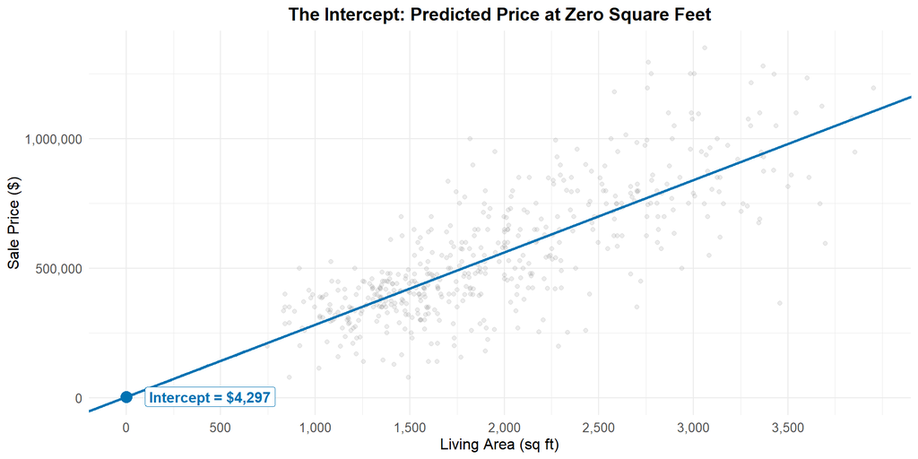

## Interpreting the intercept

Does it make sense? Maybe.

- No, a house with 0 sq ft doesn’t exist
- Yes, we could sell an empty lot

Is it reliable? No.

- Our smallest house is about 800 sqft; we have no data on bare lots
- Don’t extrapolate far beyond the observed data range

## Practice: Price vs beds

Revisit the regression of price on number of bedrooms

- Predict the sale price of a house with 3 bedrooms
- According to our model, what’s the average sale price of a house with three bedrooms?
- What is the interpretation of the slope in that model?
- What is the interpretation of the intercept in that model? Is it meaningful?

# Multiple Regression

## Multiple regression: Price vs area and beds

So far, we’ve looked at simple linear regression with one predictor.

What if we want to include both living area and number of bedrooms as predictors?

- More (useful) information should give us better predictions, right?
- What can we learn about relationships between variables?

## Multiple regression: Price vs area and beds

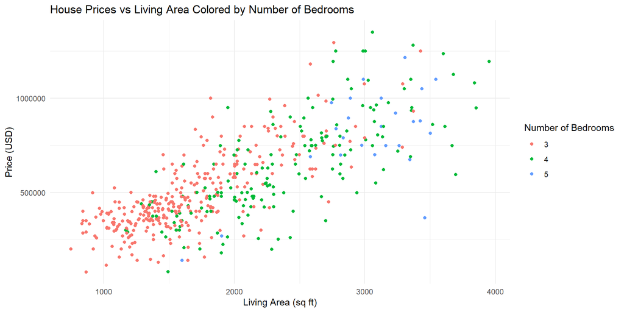

## Multiple regression fit

```r
# Multiple regression of price on area, beds
model_multi <- lm(price ~ area + beds, data = houses)
summary(model_multi)
```

```
Call:
lm(formula = price ~ area + beds, data = houses)

Residuals:
    Min      1Q  Median      3Q     Max
-554870  -84304    -988   80190  492369

Coefficients:
              Estimate Std. Error t value   Pr(>|t|)
(Intercept) 153643.148  40647.355  3.7799  0.0001756 ***
area           310.813     12.401 25.0639  < 2.2e-16 ***
beds        -61774.861  14477.102 -4.2671 0.00002366 ***
---
Signif. codes:  0 '***' 0.001 '**' 0.01 '*' 0.05 '.' 0.1 ' ' 1

Residual standard error: 153050 on 505 degrees of freedom
Multiple R-squared:  0.61533,   Adjusted R-squared:  0.6138
F-statistic:  403.9 on 2 and 505 DF,  p-value: < 2.22e-16
```

## Multiple regression fit

From the table, the regression fit (prediction equation) is:
$$\widehat{\text{price}} = 153643 + 310.81 \times \text{area} -61775 \times \text{beds}$$

- 310.81 is the *coefficient* for area (dollars per sqft)
- -61774.86 is the *coefficient* for beds (dollars per bedroom)

## Multiple regression predictions

- We can make predictions just like before: Plug in X’s and get predicted Y’s
- In R:

```r
#predict the sale price for a house with 2000 sqft and 4 bedrooms
new_data1 <- data.frame(area = 2000, beds = 4)
predict(model_multi, newdata = new_data1)
```

```
        1
528169.15
```

- Check by hand to make sure you understand!

## Interpreting the regression fit

We’ve seen three regression fits so far:

$$\widehat{\text{price}} = 20527 + 155418 \times \text{beds}$$

$$\widehat{\text{price}} = 4297 + 279.14 \times \text{area}$$

$$\widehat{\text{price}} = 153643 + 310.81 \times \text{area} -61775 \times \text{beds}$$

How do the two simple regression **slopes** compare to the corresponding multiple regression **coefficients**?

- Area’s got bigger
- Beds’ got smaller *and changed sign*
- Why???

## How do we interpret the coefficients?

- Intercept: Prediction when **all** X’s are 0 – a house with no beds and no area
- The coefficients on our two variables are similar to slopes, with one important difference.
- Bedrooms coefficient ($-61775):
  - For a one bedroom increase, holding area constant, the predicted price **decreases** by $61775

## What does “holding area constant” mean?

- If we have two houses **with identical areas** that differ by 1 bedroom, the one **with** the extra bedroom has a predicted sale price $61775 **lower**
- When we compare two houses **of the same size**, on average, the one with more bedrooms sells for less! (a decrease of $61775 per bed)
- The MLR coefficients represent *adjusted* comparisons – we are comparing houses that differ in one predictor (beds) but are identical in all other predictors *in the model* (area)

## One multiple regression is many simple regressions

We can think about the multiple regression as defining a different *simple* regression predicting price from beds **for any given area**.

The equation for that line is:

$$\widehat{\text{price}} = \underbrace{[153643 + 310.81 \times \text{area}]}_{\text{area specific intercept}} \underbrace{-61775}_{\text{common slope}} \times \text{beds}$$

## How do we interpret the coefficients?

For example:

- For a house with 1,500 sqft:
  $$\begin{align}
  \widehat{\text{price}} &= [ 153643 + 310.81 \times 1500 ] -61775 \times \text{beds}\\
  &= 619858 -61775 \times \text{beds}
  \end{align}$$
- For a house with 2,000 sqft:
  $$\begin{align}
  \widehat{\text{price}} &= [ 153643 + 310.81 \times 2000 ] -61775 \times \text{beds}\\
  &= 775263 -61775 \times \text{beds}
  \end{align}$$

## Visualizing the model fit

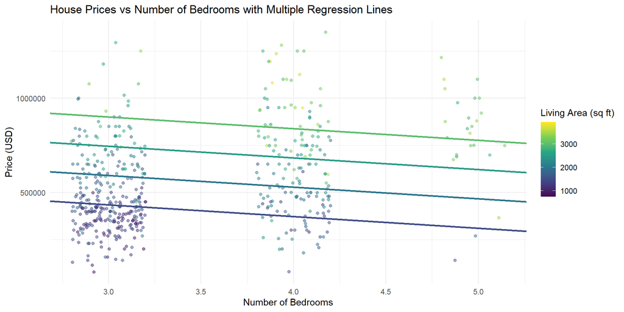

## Does the MLR estimate make sense?

In our model, if we compare two houses of the same size, the one with more bedrooms has a lower predicted price.

Does this make sense?

- If the area is the same, then a house with more bedrooms has smaller rooms overall
- If we can’t add area to the house, how do we get another bedroom?
  - Cut the living room in half?
  - Split a bedroom?
  - Do any of these add value?

## Is it consistent with the data?

Let’s do a simple exercise: Compare the average sale price for 3 and 4 bed houses of *similar* sizes

- We don’t have enough data on houses of any *single* size to compare historical prices (this is one reason to fit a model!)
- But if our story is true, when we look at subsets of houses with *similar* sizes, we should see lower average prices for 4 bed vs 3 bed houses

## Returning to the data

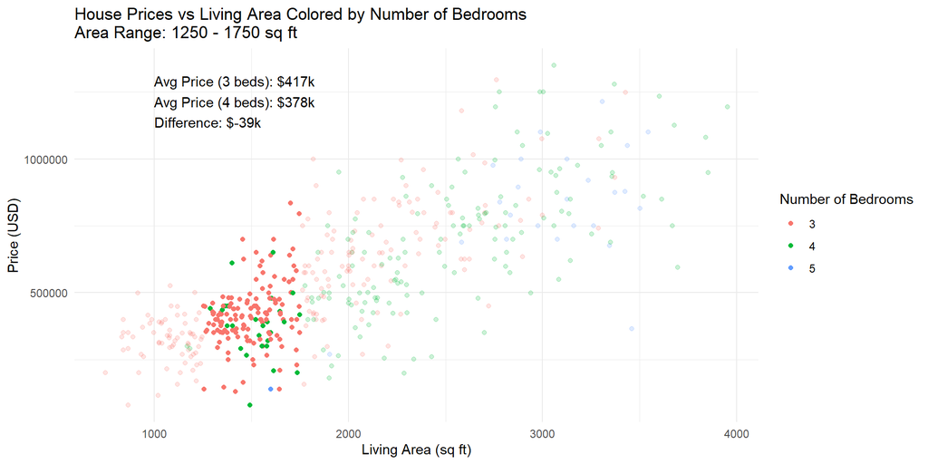

Figure 3: Area Range: 1250-1750 sq ft

## Returning to the data

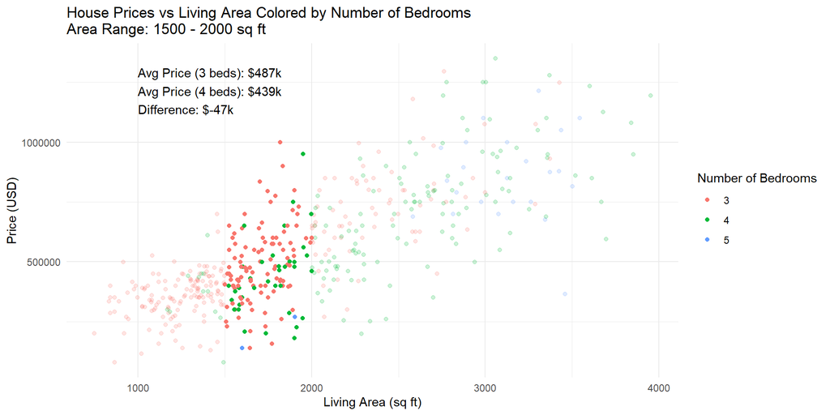

Figure 4: Area Range: 1500-2000 sq ft

## Returning to the data

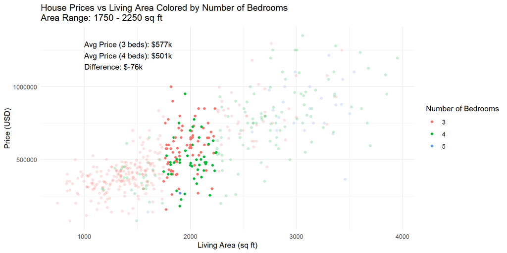

Figure 5: Area Range: 1750-2250 sq ft

## Returning to the data

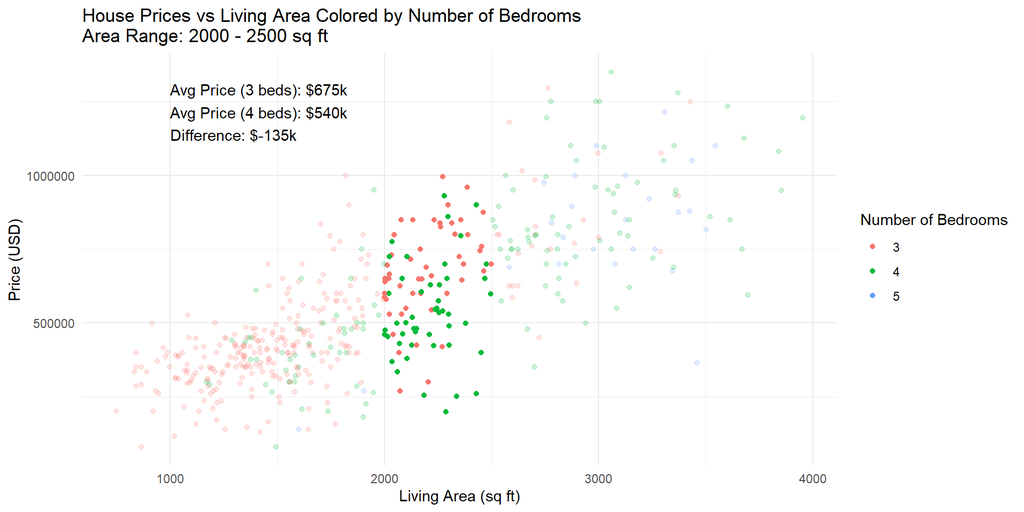

Figure 6: Area Range: 2000-2500 sq ft

## Returning to the data

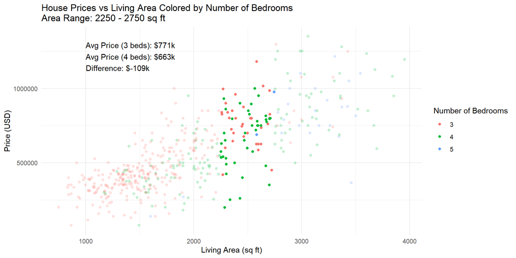

Figure 7: Area Range: 2250-2750 sq ft

## What’s going on?

- Larger houses tend to have more bedrooms (area and beds are correlated)
- Both predict sale prices
- Without area in the model, beds is a proxy for size:
  - More beds = larger house = higher price on average
  - This gives us the positive association/slope in the model with just beds

## Which model is “right”?

They both are! They just estimate different things:

- Simple regression: The overall linear relationship between beds and price, irrespective of size
- Multiple regression: The linear relationship between beds and price **when we compare houses of the same size**

Multiple regression “adjusts” or “controls” for size, by comparing like vs like.

## Interpreting the area coefficient

- In the multiple regression of price on area and beds, the coefficient for area is 310.81 dollars per sq ft
- Comparing two houses **with the same number of bedrooms** that differ in size by 1 sqft, the larger house has a predicted price that is $310.81 higher
- On average, among all houses with the same number of bedrooms, larger houses sell for more and the difference is about $310.81 per additional sqft

## What’s going on with the area coefficient?

- In the simple regression of price on area, the coefficient is 279.14 dollars per sq ft
- In the multiple regression of price on area and beds, the coefficient is 310.81 dollars per sq ft
- Why did it go up?

## Revisiting the data

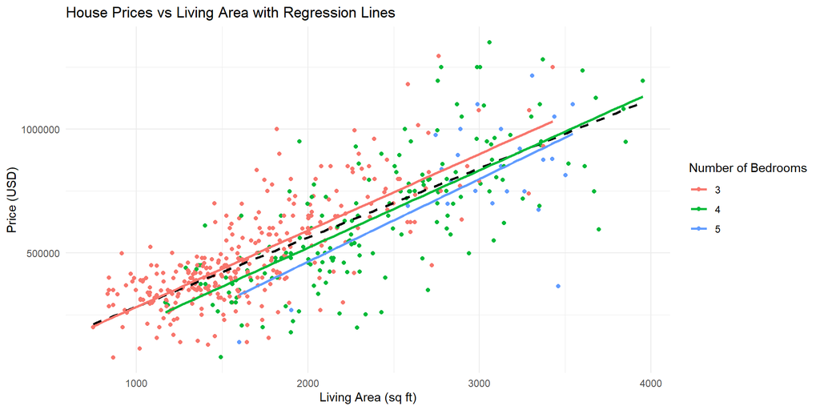

When we only compare houses of the same number of bedrooms, we do indeed get steeper slopes than the overall regression line (in black)!

## What’s going on with the area coefficient?

- In the simple regression of price on area, the coefficient is 279.14 dollars per sq ft
- In the multiple regression of price on area and beds, the coefficient is 310.81 dollars per sq ft
- Why did it go up? Without beds in the model, area was partially capturing the effect of beds!

# Example 2

*What personal characteristics about an instructor do you think are predictive of the scores they receive on student evaluations?*

[figure not shown]

## Hamermesh & Parker (2005) data set

- Student evaluations of $N=463$ instructors at UT Austin, 2000-2002
- For each instructor:
  - **eval**: average student evaluation of teacher
  - **beauty**: average beauty score from a six-student panel (z-score, 0 is average)
  - **gender**: male or female
  - **credits**: single- or multi-credit course
  - **age**: age of instructor
  - (and more…)

## Explore the data: `eval`

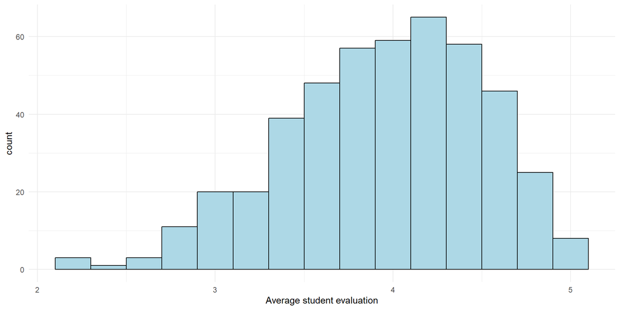

## Explore the data: `beauty`

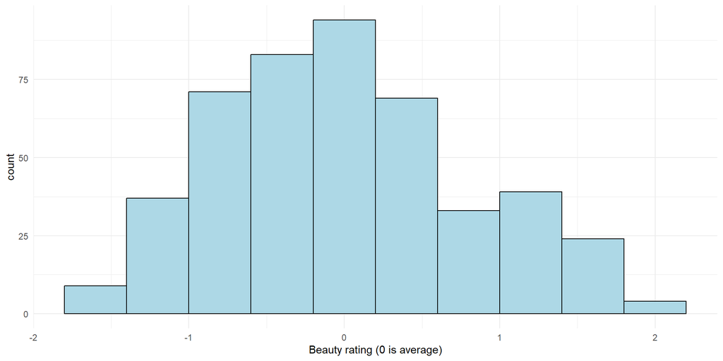

Do you think there is a positive or negative relationship between beauty and evaluations?

## Explore the data

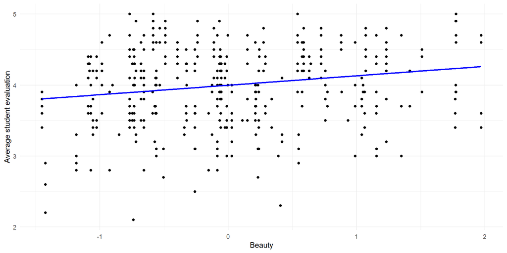

## The simple regression fit

```
Call:
lm(formula = eval ~ beauty, data = profs)

Residuals:
    Min      1Q  Median      3Q     Max
-1.8002 -0.3630  0.0725  0.4021  1.1037

Coefficients:
            Estimate Std. Error t value Pr(>|t|)
(Intercept)   3.9983     0.0253  157.73  < 2e-16 ***
beauty        0.1330     0.0322    4.13 0.000042 ***
---
Signif. codes:  0 '***' 0.001 '**' 0.01 '*' 0.05 '.' 0.1 ' ' 1

Residual standard error: 0.545 on 461 degrees of freedom
Multiple R-squared:  0.0357,    Adjusted R-squared:  0.0336
F-statistic: 17.1 on 1 and 461 DF,  p-value: 0.0000425
```

## Interpreting the intercept

Intercept:

- When beauty = 0 (average), predicted eval = 3.998 points
- The average evaluation for an average-looking instructor
- Meaningful this time!

## Interpreting the slope

Slope:

- For a one unit (standard deviation) increase in beauty, the predicted eval increases by 0.13 points
- Comparing two instructors who differ by 1 SD on beauty, on average the more attractive instructor has an eval score 0.13 points higher

## Is this the whole story?

Probably not!

- Lots of other predictors to consider – could the positive association be due to another variable that isn’t in the model yet (think bedrooms and living area)?
- Age might be important here – how?
  - On average, older instructors are probably less hot
  - As they age instructors might get better at teaching (experience) – or worse (stale or out of touch)

## Is age actually correlated with beauty?

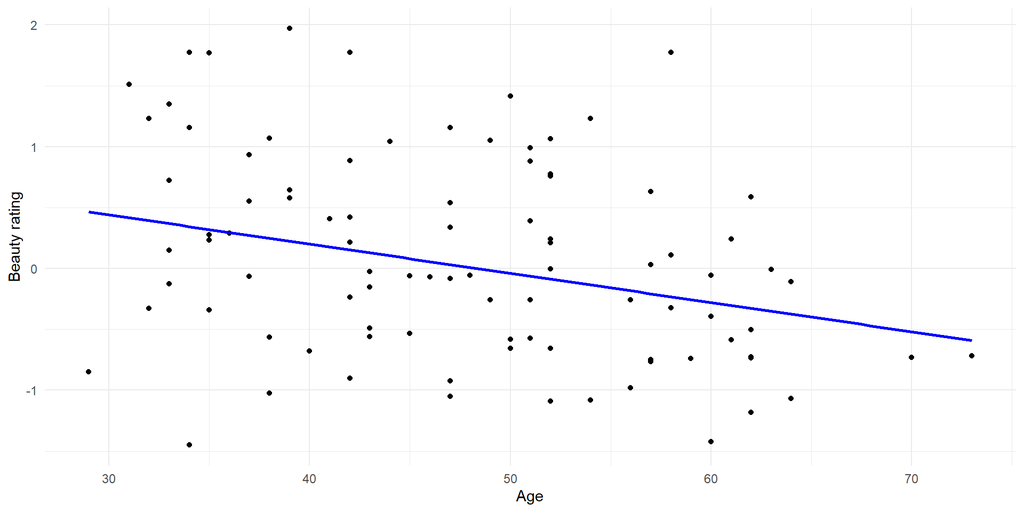

## Multiple regression: eval on beauty and age

```r
# linear regression of eval on beauty
model_beauty <-
    lm(eval ~ beauty, data = profs)
summary(model_beauty)
```

```
Call:
lm(formula = eval ~ beauty, data = profs)

Residuals:
    Min      1Q  Median      3Q     Max
-1.8002 -0.3630  0.0725  0.4021  1.1037

Coefficients:
            Estimate Std. Error t value Pr(>|t|)
(Intercept)   3.9983     0.0253  157.73  < 2e-16 ***
beauty        0.1330     0.0322    4.13 0.000042 ***
---
Signif. codes:  0 '***' 0.001 '**' 0.01 '*' 0.05 '.' 0.1 ' ' 1

Residual standard error: 0.545 on 461 degrees of freedom
Multiple R-squared:  0.0357,    Adjusted R-squared:  0.0336
F-statistic: 17.1 on 1 and 461 DF,  p-value: 0.0000425
```

```r
#linear regression of eval on beauty and age
model_beauty_age <-
    lm(eval ~ beauty + age, data = profs)
summary(model_beauty_age)
```

```
Call:
lm(formula = eval ~ beauty + age, data = profs)

Residuals:
    Min      1Q  Median      3Q     Max
-1.8024 -0.3651  0.0741  0.3991  1.1021

Coefficients:
            Estimate Std. Error t value Pr(>|t|)
(Intercept) 3.984401   0.133730   29.79  < 2e-16 ***
beauty      0.134063   0.033744    3.97 0.000082 ***
age         0.000287   0.002715    0.11     0.92
---
Signif. codes:  0 '***' 0.001 '**' 0.01 '*' 0.05 '.' 0.1 ' ' 1

Residual standard error: 0.546 on 460 degrees of freedom
Multiple R-squared:  0.0358,    Adjusted R-squared:  0.0316
F-statistic: 8.53 on 2 and 460 DF,  p-value: 0.00023
```

## Interpreting the coefficients

- In this case, *whether we compare instructors of the same age or not*, we get the same answer: Hotter instructors get higher evaluations on average.
- Good(ish) news – we ruled out one alternative explanation for the association between beauty and eval
- Are there others?

# Wrapping Up

## Summary

- As we add or remove variables in regression models, the coefficients on other variables can go up, down, or stay about the same
- It all depends on the relationships
  1. Among the predictors
  2. Between the predictors and the outcome

If we want to interpret our models, we need to think carefully about how we specify them.

## Summary

In this course we’ll learn how to build models that

- Estimate the effects we want
- Make the best possible predictions

These are not always the same!

## Next time: Errors and uncertainty

The missing part of the story so far is estimation/prediction error and uncertainty. For example:

- Does the association between beauty and evals hold among ALL instructors, or just in this sample?
  - Could we be looking at a chance association that would disappear if we could get data on everyone?

## Next time: Errors and uncertainty

The missing part of the story so far is estimation/prediction error and uncertainty. For example:

- How accurately can we predict the sale price of a house from its size and other factors?
  - How do we quantify **prediction errors**? Even with many variables our predictions will be off by some amount. How wrong should we expect to be?